# Part I - (Fordgobike Data Exploration)

## Introduction

> This data set includes information about individual rides made in a bike-sharing system covering the greater San Francisco Bay area

> **Rubric Tip**: Markup cells should have headers and text that organize your thoughts, findings, and what you plan on investigating next.

## Preliminary Wrangling

```python
# import all packages and set plots to be embedded inline
import numpy as np
import pandas as pd
import matplotlib.pyplot as plt
import seaborn as sb
from math import radians, sin, cos, acos, asin, sqrt
import datetime
from pandas.api.types import CategoricalDtype

%matplotlib inline
```

```python
# Load dataset into dataframe and display random samples
fordgobike = pd.read_csv('fordgobike_trip.csv')
fordgobike.sample(10)
```

|  | duration_sec | start_time | end_time | start_station_id | start_station_name | start_station_latitude | start_station_longitude | end_station_id | end_station_name | end_station_latitude | end_station_longitude | bike_id | user_type | member_birth_year | member_gender | bike_share_for_all_trip |
| --- | --- | --- | --- | --- | --- | --- | --- | --- | --- | --- | --- | --- | --- | --- | --- | --- |
| 27763 | 516 | 2019-02-25 09:15:00.6400 | 2019-02-25 09:23:36.8990 | 61.0 | Howard St at 8th St | 37.776513 | -122.411306 | 114.0 | Rhode Island St at 17th St | 37.764478 | -122.402570 | 5826 | Subscriber | 1988.0 | Male | No |
| 153101 | 683 | 2019-02-06 13:32:03.1800 | 2019-02-06 13:43:27.0770 | 299.0 | Bestor Art Park | 37.323678 | -121.874119 | 280.0 | San Fernando St at 7th St | 37.337122 | -121.883215 | 1477 | Subscriber | 1995.0 | Female | Yes |
| 57529 | 552 | 2019-02-21 08:11:40.0930 | 2019-02-21 08:20:52.2980 | 30.0 | San Francisco Caltrain (Townsend St at 4th St) | 37.776598 | -122.395282 | 21.0 | Montgomery St BART Station (Market St at 2nd St) | 37.789625 | -122.400811 | 2623 | Subscriber | 1985.0 | Male | No |
| 9727 | 795 | 2019-02-28 05:34:08.0840 | 2019-02-28 05:47:23.6320 | 122.0 | 19th St at Mission St | 37.760299 | -122.418892 | 22.0 | Howard St at Beale St | 37.789756 | -122.394643 | 6574 | Subscriber | 1980.0 | Male | No |
| 69701 | 765 | 2019-02-19 19:01:11.0470 | 2019-02-19 19:13:56.1030 | 203.0 | Webster St at 2nd St | 37.795195 | -122.273970 | 181.0 | Grand Ave at Webster St | 37.811377 | -122.265192 | 4787 | Subscriber | 1976.0 | Female | No |
| 13776 | 1333 | 2019-02-27 14:33:54.3460 | 2019-02-27 14:56:08.1820 | 276.0 | Julian St at The Alameda | 37.332233 | -121.912516 | 276.0 | Julian St at The Alameda | 37.332233 | -121.912516 | 4002 | Subscriber | 1993.0 | Female | Yes |
| 89046 | 412 | 2019-02-16 16:35:19.7950 | 2019-02-16 16:42:12.2450 | 73.0 | Pierce St at Haight St | 37.771793 | -122.433708 | 54.0 | Alamo Square (Steiner St at Fulton St) | 37.777547 | -122.433274 | 4949 | Customer | NaN | NaN | No |
| 125566 | 206 | 2019-02-11 07:08:04.9730 | 2019-02-11 07:11:31.4920 | 66.0 | 3rd St at Townsend St | 37.778742 | -122.392741 | 91.0 | Berry St at King St | 37.771762 | -122.398438 | 5540 | Subscriber | 1982.0 | Male | No |
| 96686 | 685 | 2019-02-15 09:51:22.2110 | 2019-02-15 10:02:47.3960 | 115.0 | Jackson Playground | 37.765026 | -122.398773 | 27.0 | Beale St at Harrison St | 37.788059 | -122.391865 | 5035 | Subscriber | 1992.0 | Male | No |
| 19912 | 270 | 2019-02-26 15:06:27.3300 | 2019-02-26 15:10:57.9330 | 195.0 | Bay Pl at Vernon St | 37.812314 | -122.260779 | 197.0 | El Embarcadero at Grand Ave | 37.808848 | -122.249680 | 6057 | Subscriber | 1975.0 | Female | No |

```python
# Dimension of dataframe
fordgobike.shape
```

```
(183412, 16)
```

```python
# Summary statistics for numerical variables in the dataframe
fordgobike.describe()
```

|  | duration_sec | start_station_id | start_station_latitude | start_station_longitude | end_station_id | end_station_latitude | end_station_longitude | bike_id | member_birth_year |
| --- | --- | --- | --- | --- | --- | --- | --- | --- | --- |
| count | 183412.000000 | 183215.000000 | 183412.000000 | 183412.000000 | 183215.000000 | 183412.000000 | 183412.000000 | 183412.000000 | 175147.000000 |
| mean | 726.078435 | 138.590427 | 37.771223 | -122.352664 | 136.249123 | 37.771427 | -122.352250 | 4472.906375 | 1984.806437 |
| std | 1794.389780 | 111.778864 | 0.099581 | 0.117097 | 111.515131 | 0.099490 | 0.116673 | 1664.383394 | 10.116689 |
| min | 61.000000 | 3.000000 | 37.317298 | -122.453704 | 3.000000 | 37.317298 | -122.453704 | 11.000000 | 1878.000000 |
| 25% | 325.000000 | 47.000000 | 37.770083 | -122.412408 | 44.000000 | 37.770407 | -122.411726 | 3777.000000 | 1980.000000 |
| 50% | 514.000000 | 104.000000 | 37.780760 | -122.398285 | 100.000000 | 37.781010 | -122.398279 | 4958.000000 | 1987.000000 |
| 75% | 796.000000 | 239.000000 | 37.797280 | -122.286533 | 235.000000 | 37.797320 | -122.288045 | 5502.000000 | 1992.000000 |
| max | 85444.000000 | 398.000000 | 37.880222 | -121.874119 | 398.000000 | 37.880222 | -121.874119 | 6645.000000 | 2001.000000 |

```python
# List all column names
list(fordgobike)
```

```
['duration_sec',
 'start_time',
 'end_time',
 'start_station_id',
 'start_station_name',
 'start_station_latitude',
 'start_station_longitude',
 'end_station_id',
 'end_station_name',
 'end_station_latitude',
 'end_station_longitude',
 'bike_id',
 'user_type',
 'member_birth_year',
 'member_gender',
 'bike_share_for_all_trip']
```

```python
# structure of dataframe
fordgobike.info()
```

```
<class 'pandas.core.frame.DataFrame'>
RangeIndex: 183412 entries, 0 to 183411
Data columns (total 16 columns):
 #   Column                   Non-Null Count   Dtype
---  ------                   --------------   -----
 0   duration_sec             183412 non-null  int64
 1   start_time               183412 non-null  object
 2   end_time                 183412 non-null  object
 3   start_station_id         183215 non-null  float64
 4   start_station_name       183215 non-null  object
 5   start_station_latitude   183412 non-null  float64
 6   start_station_longitude  183412 non-null  float64
 7   end_station_id           183215 non-null  float64
 8   end_station_name         183215 non-null  object
 9   end_station_latitude     183412 non-null  float64
 10  end_station_longitude    183412 non-null  float64
 11  bike_id                  183412 non-null  int64
 12  user_type                183412 non-null  object
 13  member_birth_year        175147 non-null  float64
 14  member_gender            175147 non-null  object
 15  bike_share_for_all_trip  183412 non-null  object
dtypes: float64(7), int64(2), object(7)
memory usage: 22.4+ MB
```

```python
# Count the values in the bike_share_for_all_trip column
fordgobike.bike_share_for_all_trip.value_counts()
```

```
No     166053
Yes     17359
Name: bike_share_for_all_trip, dtype: int64
```

```python
# Check for duplicats
fordgobike.duplicated().value_counts()
```

```
False    183412
dtype: int64
```

```python
# Counts values for user_type
fordgobike.user_type.value_counts()
```

```
Subscriber    163544
Customer       19868
Name: user_type, dtype: int64
```

### Assessment

- There are miising values in the dataset
- Start_time column data type is object instead of datetime
- End_time column data type is object instead of datetime
- Start_station_id data type is float instead of object
- End_station_id data type is float instead of object
- Bike_id data type is integer instead of object
- Member_birth_year is float instead of datetime
- Coordinate points columns are available but not distance between the start and end point
- Member_birth_year can be used to compute the age of members

### Cleaning

```python
#create a copy of dataset for cleaning
fordgobike_clean = fordgobike.copy()
```

### Issue

There are miising values in the dataset

#### define

- Filter out the missing data

#### code

```python
fordgobike_clean = fordgobike_clean[~(fordgobike_clean.isna().any(axis=1))]
```

#### Test

```python
fordgobike_clean.info()
```

```
<class 'pandas.core.frame.DataFrame'>
Int64Index: 174952 entries, 0 to 183411
Data columns (total 16 columns):
 #   Column                   Non-Null Count   Dtype
---  ------                   --------------   -----
 0   duration_sec             174952 non-null  int64
 1   start_time               174952 non-null  object
 2   end_time                 174952 non-null  object
 3   start_station_id         174952 non-null  float64
 4   start_station_name       174952 non-null  object
 5   start_station_latitude   174952 non-null  float64
 6   start_station_longitude  174952 non-null  float64
 7   end_station_id           174952 non-null  float64
 8   end_station_name         174952 non-null  object
 9   end_station_latitude     174952 non-null  float64
 10  end_station_longitude    174952 non-null  float64
 11  bike_id                  174952 non-null  int64
 12  user_type                174952 non-null  object
 13  member_birth_year        174952 non-null  float64
 14  member_gender            174952 non-null  object
 15  bike_share_for_all_trip  174952 non-null  object
dtypes: float64(7), int64(2), object(7)
memory usage: 22.7+ MB
```

### Issue

- Start_time column data type is object instead of datetime
- End_time column data type is object instead of datetime
- Start_station_id data type is float instead of object
- End_station_id data type is float instead of object
- Bike_id data type is integer instead of object
- Member_birth_year is float instead of Integer or Datetime

#### define

- Change the data types of the following columns start_time, end_time, start_station_id, end_station_id, bike_id, member_birth_year

#### code

```python
fordgobike_clean[['start_time','end_time',]] = fordgobike_clean[['start_time','end_time']].apply(pd.to_datetime)
fordgobike_clean = fordgobike_clean.astype({'start_station_id': 'object', 'end_station_id': 'object', 'bike_id': 'object', 'member_birth_year': 'int'})
```

#### Test

```python
fordgobike_clean.info()
```

```
<class 'pandas.core.frame.DataFrame'>
Int64Index: 174952 entries, 0 to 183411
Data columns (total 16 columns):
 #   Column                   Non-Null Count   Dtype
---  ------                   --------------   -----
 0   duration_sec             174952 non-null  int64
 1   start_time               174952 non-null  datetime64[ns]
 2   end_time                 174952 non-null  datetime64[ns]
 3   start_station_id         174952 non-null  object
 4   start_station_name       174952 non-null  object
 5   start_station_latitude   174952 non-null  float64
 6   start_station_longitude  174952 non-null  float64
 7   end_station_id           174952 non-null  object
 8   end_station_name         174952 non-null  object
 9   end_station_latitude     174952 non-null  float64
 10  end_station_longitude    174952 non-null  float64
 11  bike_id                  174952 non-null  object
 12  user_type                174952 non-null  object
 13  member_birth_year        174952 non-null  int32
 14  member_gender            174952 non-null  object
 15  bike_share_for_all_trip  174952 non-null  object
dtypes: datetime64[ns](2), float64(4), int32(1), int64(1), object(8)
memory usage: 22.0+ MB
```

### Issue

Coordinate points columns are available but not distance between the start and end point

#### define

- Compute distance in km from the start point to the end point using the coordinate columns

#### code

```python
# Create function that converts geographical coordinated to distance in kilometers
def haversine(row):
    """
    Calculate the great circle distance between two points
    on the earth (specified in decimal degrees)
    """
    # convert decimal degrees to radians
    lon1 = row['start_station_longitude']
    lat1 = row['start_station_latitude']
    lon2 = row['end_station_longitude']
    lat2 = row['end_station_latitude']

    lon1, lat1, lon2, lat2 = map(radians, [lon1, lat1, lon2, lat2])
    # haversine formula
    dlon = lon2 - lon1
    dlat = lat2 - lat1
    a = sin(dlat/2)**2 + cos(lat1) * cos(lat2) * sin(dlon/2)**2
    c = 2 * asin(sqrt(a))
    km = 6367 * c
    return km
```

```python
fordgobike_clean['distance'] = fordgobike_clean.apply(haversine, axis=1)
```

#### Test

```python
fordgobike_clean.head()
```

|  | duration_sec | start_time | end_time | start_station_id | start_station_name | start_station_latitude | start_station_longitude | end_station_id | end_station_name | end_station_latitude | end_station_longitude | bike_id | user_type | member_birth_year | member_gender | bike_share_for_all_trip | distance |
| --- | --- | --- | --- | --- | --- | --- | --- | --- | --- | --- | --- | --- | --- | --- | --- | --- | --- |
| 0 | 52185 | 2019-02-28 17:32:10.145 | 2019-03-01 08:01:55.975 | 21.0 | Montgomery St BART Station (Market St at 2nd St) | 37.789625 | -122.400811 | 13.0 | Commercial St at Montgomery St | 37.794231 | -122.402923 | 4902 | Customer | 1984 | Male | No | 0.544367 |
| 2 | 61854 | 2019-02-28 12:13:13.218 | 2019-03-01 05:24:08.146 | 86.0 | Market St at Dolores St | 37.769305 | -122.426826 | 3.0 | Powell St BART Station (Market St at 4th St) | 37.786375 | -122.404904 | 5905 | Customer | 1972 | Male | No | 2.702847 |
| 3 | 36490 | 2019-02-28 17:54:26.010 | 2019-03-01 04:02:36.842 | 375.0 | Grove St at Masonic Ave | 37.774836 | -122.446546 | 70.0 | Central Ave at Fell St | 37.773311 | -122.444293 | 6638 | Subscriber | 1989 | Other | No | 0.260575 |
| 4 | 1585 | 2019-02-28 23:54:18.549 | 2019-03-01 00:20:44.074 | 7.0 | Frank H Ogawa Plaza | 37.804562 | -122.271738 | 222.0 | 10th Ave at E 15th St | 37.792714 | -122.248780 | 4898 | Subscriber | 1974 | Male | Yes | 2.407789 |
| 5 | 1793 | 2019-02-28 23:49:58.632 | 2019-03-01 00:19:51.760 | 93.0 | 4th St at Mission Bay Blvd S | 37.770407 | -122.391198 | 323.0 | Broadway at Kearny | 37.798014 | -122.405950 | 5200 | Subscriber | 1959 | Male | No | 3.330111 |

### Issue

Member_birth_year can be used to compute the age of members

#### define

- Compute the age of members by subtracting the member_birth_year from the current year

#### code

```python
current_year = int(datetime.datetime.now().year)
fordgobike_clean['age'] = current_year - fordgobike_clean['member_birth_year']
```

#### Test

```python
fordgobike_clean.head()
```

|  | duration_sec | start_time | end_time | start_station_id | start_station_name | start_station_latitude | start_station_longitude | end_station_id | end_station_name | end_station_latitude | end_station_longitude | bike_id | user_type | member_birth_year | member_gender | bike_share_for_all_trip | distance | age |
| --- | --- | --- | --- | --- | --- | --- | --- | --- | --- | --- | --- | --- | --- | --- | --- | --- | --- | --- |
| 0 | 52185 | 2019-02-28 17:32:10.145 | 2019-03-01 08:01:55.975 | 21.0 | Montgomery St BART Station (Market St at 2nd St) | 37.789625 | -122.400811 | 13.0 | Commercial St at Montgomery St | 37.794231 | -122.402923 | 4902 | Customer | 1984 | Male | No | 0.544367 | 39 |
| 2 | 61854 | 2019-02-28 12:13:13.218 | 2019-03-01 05:24:08.146 | 86.0 | Market St at Dolores St | 37.769305 | -122.426826 | 3.0 | Powell St BART Station (Market St at 4th St) | 37.786375 | -122.404904 | 5905 | Customer | 1972 | Male | No | 2.702847 | 51 |
| 3 | 36490 | 2019-02-28 17:54:26.010 | 2019-03-01 04:02:36.842 | 375.0 | Grove St at Masonic Ave | 37.774836 | -122.446546 | 70.0 | Central Ave at Fell St | 37.773311 | -122.444293 | 6638 | Subscriber | 1989 | Other | No | 0.260575 | 34 |
| 4 | 1585 | 2019-02-28 23:54:18.549 | 2019-03-01 00:20:44.074 | 7.0 | Frank H Ogawa Plaza | 37.804562 | -122.271738 | 222.0 | 10th Ave at E 15th St | 37.792714 | -122.248780 | 4898 | Subscriber | 1974 | Male | Yes | 2.407789 | 49 |
| 5 | 1793 | 2019-02-28 23:49:58.632 | 2019-03-01 00:19:51.760 | 93.0 | 4th St at Mission Bay Blvd S | 37.770407 | -122.391198 | 323.0 | Broadway at Kearny | 37.798014 | -122.405950 | 5200 | Subscriber | 1959 | Male | No | 3.330111 | 64 |

```python
fordgobike_clean.info()
```

```
<class 'pandas.core.frame.DataFrame'>
Int64Index: 174952 entries, 0 to 183411
Data columns (total 18 columns):
 #   Column                   Non-Null Count   Dtype
---  ------                   --------------   -----
 0   duration_sec             174952 non-null  int64
 1   start_time               174952 non-null  datetime64[ns]
 2   end_time                 174952 non-null  datetime64[ns]
 3   start_station_id         174952 non-null  object
 4   start_station_name       174952 non-null  object
 5   start_station_latitude   174952 non-null  float64
 6   start_station_longitude  174952 non-null  float64
 7   end_station_id           174952 non-null  object
 8   end_station_name         174952 non-null  object
 9   end_station_latitude     174952 non-null  float64
 10  end_station_longitude    174952 non-null  float64
 11  bike_id                  174952 non-null  object
 12  user_type                174952 non-null  object
 13  member_birth_year        174952 non-null  int32
 14  member_gender            174952 non-null  object
 15  bike_share_for_all_trip  174952 non-null  object
 16  distance                 174952 non-null  float64
 17  age                      174952 non-null  int32
dtypes: datetime64[ns](2), float64(5), int32(2), int64(1), object(8)
memory usage: 24.0+ MB
```

### What is/are the main feature(s) of interest in your dataset?

i'm interested in a number of features such as ;

- How long does the average trip take
- Other factors that may influence average trip duration such as the user_type, member_gender, distance covered or age

### What features in the dataset do you think will help support your investigation into your feature(s) of interest?

> I expect that the the distance between the start station of the bike to the end station will play a significant role in predicting the duration of rides. Also, the Age of the rider may have some influence on the duration and distance covered while the member gender may also play a role in determininig ride duration. i do not however think that the user type play any significant role if any.

## Univariate Exploration

### What is the distribution of the main variable of interest: duration_sec

```python
# Mean duration of ride
fordgobike_clean.duration_sec.mean()
```

```
704.0027436096758
```

The code above shows the mean duration of ride in seconds by all the riders in the dataset

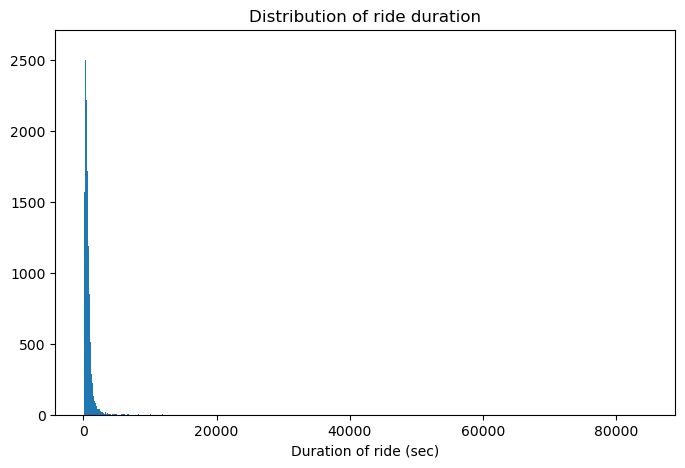

```python
# Plot histogram to show distribution of ride duration
binsize = 50
bins = np.arange(0, fordgobike_clean['duration_sec'].max()+binsize, 10)

plt.figure(figsize=[8, 5])
plt.hist(data = fordgobike_clean, x = 'duration_sec', bins = bins)
plt.xlabel('Duration of ride (sec)');
plt.title('Distribution of ride duration');
```

Standard plot of the distribubtion of ride duration and it shows a long tail distribution hence the need for log transformation

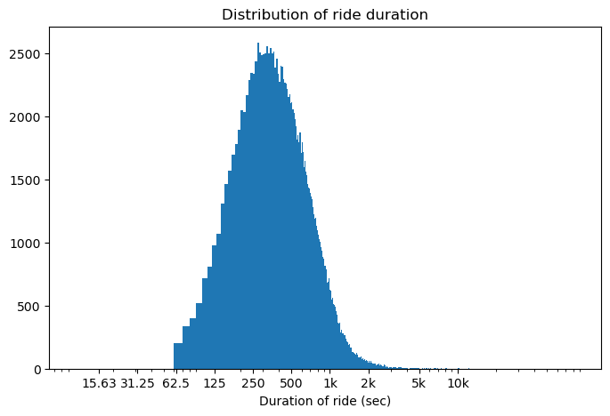

```python
# Plot histogram to show distribution of ride duration
binsize = 50
bins = np.arange(0, fordgobike_clean['duration_sec'].max()+binsize, 10)

plt.figure(figsize=[8, 5])
plt.hist(data = fordgobike_clean, x = 'duration_sec', bins = bins)
plt.xscale('log')
plt.xlabel('Duration of ride (sec)')
plt.xticks([15.63,31.25,62.5,125, 250, 500, 1e3, 2e3, 5e3, 1e4], [15.63,31.25,62.5,125,250, 500, '1k', '2k', '5k', '10k'])
plt.title('Distribution of ride duration');
```

After log tranformation, the duration_sec variable shows somewhat normal distribution

```python
q_low = fordgobike_clean["duration_sec"].quantile(0.01)
q_hi  = fordgobike_clean["duration_sec"].quantile(0.99)

fordgobike_clean = fordgobike_clean[(fordgobike_clean["duration_sec"] < q_hi) & (fordgobike_clean["duration_sec"] > q_low)]
```

The codes above removes the outliers in duration_sec column for further exploration

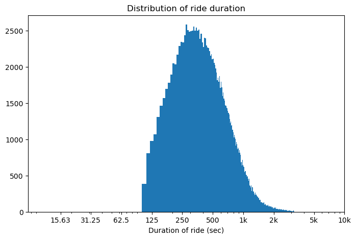

```python
# Plot histogram to show distribution of ride duration
binsize = 50
bins = np.arange(0, fordgobike_clean['duration_sec'].max()+binsize, 10)

plt.figure(figsize=[8, 5])
plt.hist(data = fordgobike_clean, x = 'duration_sec', bins = bins)
plt.xscale('log')
plt.xlabel('Duration of ride (sec)')
plt.xticks([15.63,31.25,62.5,125, 250, 500, 1e3, 2e3, 5e3, 1e4], [15.63,31.25,62.5,125,250, 500, '1k', '2k', '5k', '10k'])
plt.title('Distribution of ride duration');
```

The codes above shows the distribution of duration of ride on a log scale after the lower and upper outliers had been removed

### Distribution of Distance covered

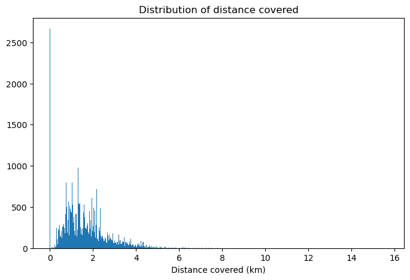

```python
# Plot histogram to show distribution of distance covered
binsize = 0.005
bins = np.arange(0, fordgobike_clean['distance'].max()+binsize, 0.005)
plt.figure(figsize=[8, 5])
plt.hist(data = fordgobike_clean, x = 'distance', bins = bins)
plt.xlabel('Distance covered (km)')
plt.title('Distribution of distance covered');
```

The standard distribution of distance show the need to zoom to the distribution in the far left

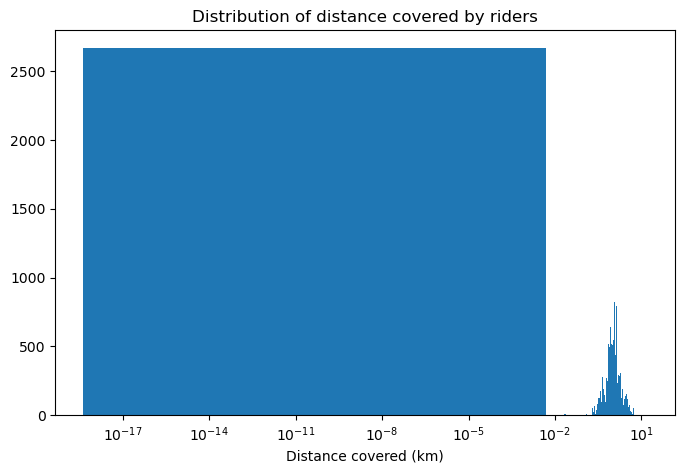

```python
# Plot histogram to show distribution of distance covered
binsize = 0.005
bins = np.arange(0, fordgobike_clean['distance'].max()+binsize, 0.005)

plt.figure(figsize=[8, 5])
plt.hist(data = fordgobike_clean, x = 'distance', bins = bins)

plt.xscale('log')
plt.xlabel('Distance covered (km)')
plt.title('Distribution of distance covered by riders');
```

A log transformation of the distance covered showed that there were very low data points in the in the distribution

```python
q_low = fordgobike_clean["distance"].quantile(0.01)
q_hi  = fordgobike_clean["distance"].quantile(0.99)

fordgobike_clean = fordgobike_clean[(fordgobike_clean["distance"] < q_hi) & (fordgobike_clean["distance"] > q_low)]
```

The codes above removes the lower and upper outliers in the distance column

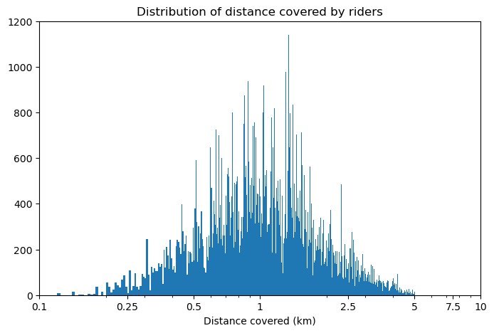

```python
# Plot histogram to show distribution of distance covered
binsize = 0.005
bins = np.arange(0, fordgobike_clean['distance'].max()+binsize, 0.005)
plt.figure(figsize=[8, 5])
plt.hist(data = fordgobike_clean, x = 'distance', bins = bins)

plt.xscale('log')
plt.xlim([0.1,10])
plt.ylim([0, 1200])
plt.xticks([0.1, 0.25, 0.5, 1, 2.5, 5, 7.5, 10], [0.1, 0.25, 0.5, 1, 2.5, 5, 7.5, 10])
plt.xlabel('Distance covered (km)')
plt.title('Distribution of distance covered by riders');
```

Distribution of distance covered by riders after log transformation and removal of lower and upper outliers showed a normally distributed data

### Age distribution of riders

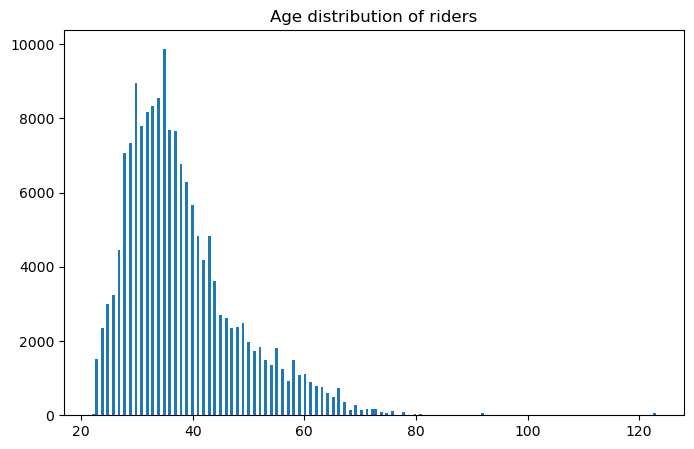

```python
# Plot histogram to show distribution of riders age
plt.figure(figsize=[8, 5])
plt.hist(data = fordgobike_clean, x = 'age', bins = 200)
plt.title('Age distribution of riders');
```

The riders age where skewed to the right

```python
q_low = fordgobike_clean["age"].quantile(0.01)
q_hi  = fordgobike_clean["age"].quantile(0.99)

fordgobike_clean = fordgobike_clean[(fordgobike_clean["age"] < q_hi) & (fordgobike_clean["age"] > q_low)]
```

The codes above removes the lower and upper outliers from the age variable

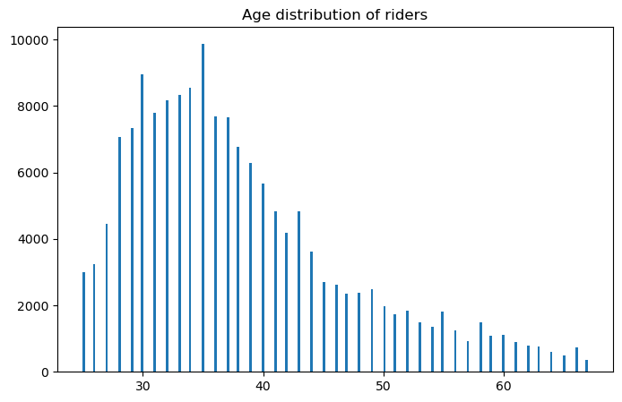

```python
# Plot histogram to show distribution of riders age
plt.figure(figsize=[8, 5])
plt.hist(data = fordgobike_clean, x = 'age', bins = 200)
plt.title('Age distribution of riders');
```

The distribution of age was still skewed to the right even after the outliers had been removed

### Distribution of Gender

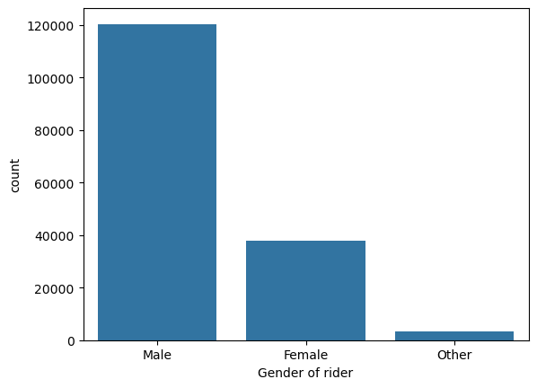

```python
# Plot histogram to show distribution of gender
gender_order = ['Male', 'Female', 'Other']
g_order = CategoricalDtype(gender_order, ordered=True)
fordgobike_clean['member_gender'] = fordgobike_clean['member_gender'].astype(g_order)

default_color = sb.color_palette()[0]
sb.countplot(data = fordgobike_clean, x = 'member_gender', color = default_color)
plt.xlabel('Gender of rider');
```

The distribution above shows that the majority of the rider were males followed by the female gender and lastly the other gender

### Distribution of user types in the data set

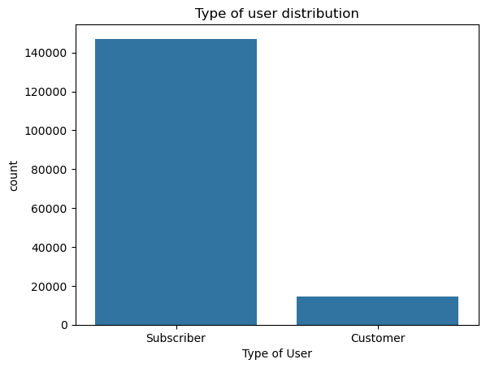

```python
# Plot histogram to show distribution of user type
default_color = sb.color_palette()[0]
sb.countplot(data = fordgobike_clean, x = 'user_type', color = default_color)
plt.xlabel('Type of User')
plt.title('Type of user distribution');
```

Majority of the users were mostly subcribers while very few were customers

```python
# Mean duration grouped by gender
fordgobike_clean.groupby('member_gender')['duration_sec'].mean()
```

```
member_gender
Male      581.366420
Female    650.895404
Other     640.257057
Name: duration_sec, dtype: float64
```

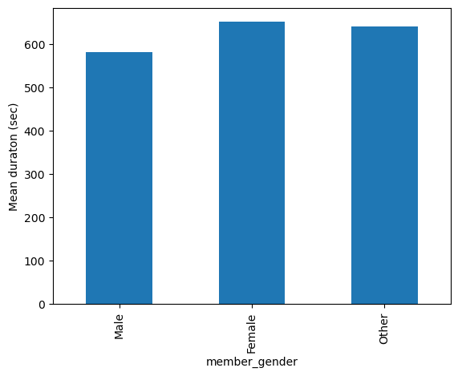

```python
# Mean duration vs gender barplot
fordgobike_clean.groupby('member_gender')['duration_sec'].mean().plot(kind = 'bar')
plt.ylabel('Mean duraton (sec)')
```

### Discuss the distribution(s) of your variable(s) of interest. Were there any unusual points? Did you need to perform any transformations?

> The column duration_sec and distance covered by riders were tranformed into log scale due to long tail and outliers

### Of the features you investigated, were there any unusual distributions? Did you perform any operations on the data to tidy, adjust, or change the form of the data? If so, why did you do this?

> One of the features needed was distance between the start point and end point which had to be computed from columns such as start_station_latitude, start_station_longitude, end_station_latitude and end_station_longitude into a new column called distance.

## Bivariate Exploration

> In this section, investigate relationships between pairs of variables in your data. Make sure the variables that you cover here have been introduced in some fashion in the previous section (univariate exploration).

### Assessment of the Pairwise correlations present between numeric features in the data.

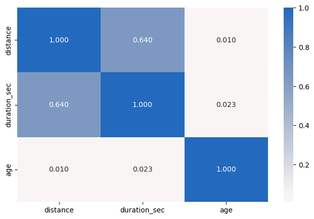

```python
# correlation of numerical variables
plt.figure(figsize = [8, 5])
sb.heatmap(fordgobike_clean[['distance', 'duration_sec', 'age']].corr(), annot = True, fmt = '.3f',
           cmap = 'vlag_r', center = 0);
```

The heatmap above shows positive linear correlation between duration and distance while the age of the riders doesn't seem to have any significant correlation with duration or distance

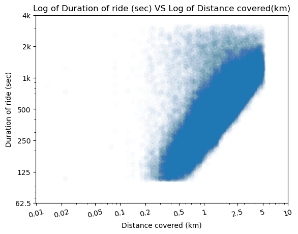

```python
# Bivaraiate analysis of duration and distance
plt.scatter(data = fordgobike_clean, x = 'distance', y = 'duration_sec', alpha = 0.01)
plt.yscale('log')
plt.xscale('log')
plt.xlabel('Distance covered (km)')
plt.ylabel('Duration of ride (sec)')
plt.yticks([62.5, 125, 250, 500, 1000, 2000, 4000], [62.5, 125, 250, 500, '1k', '2k', '4k'])
plt.xticks([0.01, 0.02, 0.05, 0.1, 0.2, 0.5, 1, 2.5, 5, 10], [0.01, 0.02, 0.05, 0.1, 0.2, 0.5, 1, 2.5, 5, 10])
plt.xticks(rotation = 15)
plt.title('Log of Duration of ride (sec) VS Log of Distance covered(km)');
```

There's a positive linear relationship between log of duration of ride and the log of distance covered by the riders

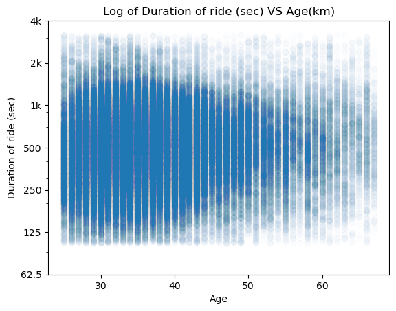

```python
# Bivaraiate analysis of duration and age
plt.scatter(data = fordgobike_clean, x = 'age', y = 'duration_sec', alpha = 0.01)
plt.yscale('log')
plt.xlabel('Age')
plt.ylabel('Duration of ride (sec)')
plt.yticks([62.5, 125, 250, 500, 1000, 2000, 4000], [62.5, 125, 250, 500, '1k', '2k', '4k'])
plt.title('Log of Duration of ride (sec) VS Age(km)');
```

Surprisingly there seems to be no relationship between duration of rides and age as it is expected that younger riders would ride faster than the older riders due to youthful energy

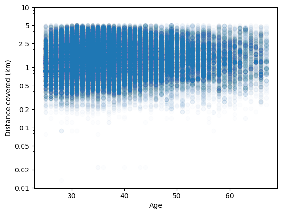

```python
# Bivaraiate analysis of distance and age
plt.scatter(data = fordgobike_clean, x = 'age', y = 'distance', alpha = 0.01)
plt.yscale('log')
plt.xlabel('Age')
plt.ylabel('Distance covered (km)')
plt.yticks([0.01, 0.02, 0.05, 0.1, 0.2, 0.5, 1, 2.5, 5, 10], [0.01, 0.02, 0.05, 0.1, 0.2, 0.5, 1, 2.5, 5, 10]) ;
```

Similarly there seems to be no relationship between distances covered by riders and age as it is expected that younger riders would cover more distance compared to the older riders

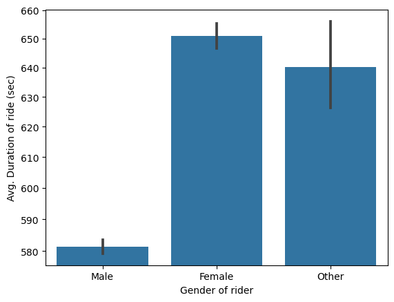

```python
# Bivaraiate analysis of duration and gender
sb.barplot(data = fordgobike_clean, x = 'member_gender', y = 'duration_sec', order = gender_order, color = default_color)
plt.yscale('log')
plt.xlabel('Gender of rider')
plt.ylabel('Avg. Duration of ride (sec)')
plt.yticks(np.arange(580, 660+10, 10), np.arange(580, 660+10, 10));
```

Distribution across each gender with respect to the the average duration of ride shows that the female riders uses the highest average duration for their rides followed by the other gender and male having the least average duration of ride

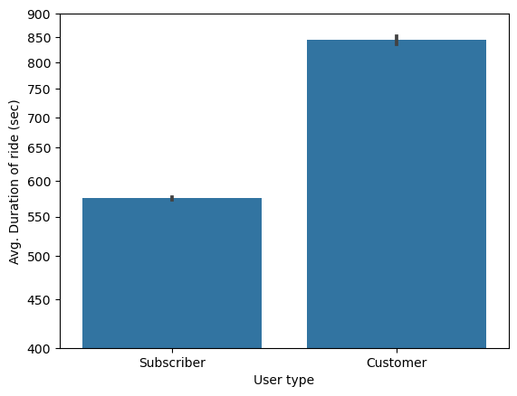

```python
# Bivaraiate analysis of duration and user type
sb.barplot(data = fordgobike_clean, x = 'user_type', y = 'duration_sec', color = default_color)
plt.yscale('log')
plt.xlabel('User type')
plt.ylabel('Avg. Duration of ride (sec)')
plt.yticks(np.arange(400, 900+50, 50), np.arange(400, 900+50, 50));
```

The average duration of ride among the customers were higher than that of the subscribers

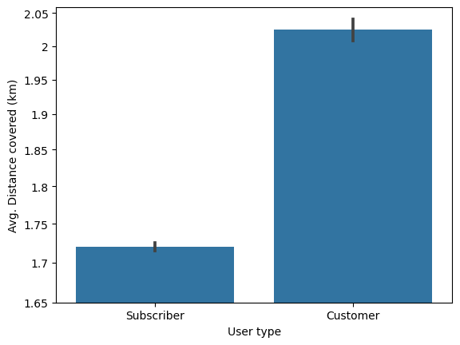

```python
# Bivaraiate analysis of distance and user type
sb.barplot(data = fordgobike_clean, x = 'user_type', y = 'distance', color = default_color)
plt.yscale('log')
plt.xlabel('User type')
plt.ylabel('Avg. Distance covered (km)')
plt.yticks(np.arange(1.6, 2+0.05, 0.05), [1.65, 1.7, 1.75, 1.8, 1.85, 1.9, 1.95, 2, 2.05]);
```

```python
# Mean distance by user type
fordgobike_clean.groupby('user_type')['distance'].mean()
```

[output not shown]

Similarly, the average distance covered by the customers were also a bit higher than that of the subscribers

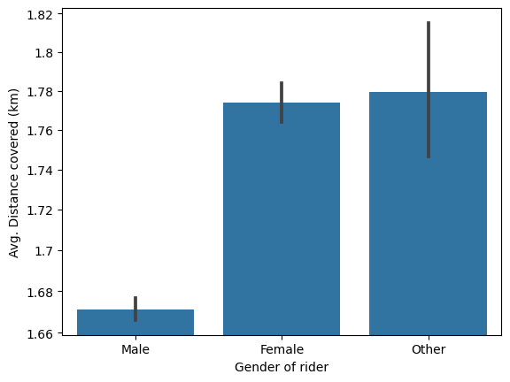

```python
# Barplot of distance and gender
sb.barplot(data = fordgobike_clean, x = 'member_gender', y = 'distance', order = gender_order, color = default_color)
plt.yscale('log')
plt.xlabel('Gender of rider')
plt.ylabel('Avg. Distance covered (km)')
plt.yticks(np.arange(1.66, 1.8+0.02, 0.02), np.arange(1.66, 1.8+0.02, 0.02));
```

Other gender seem to cover more average distance than Females while the Male gender convered the least

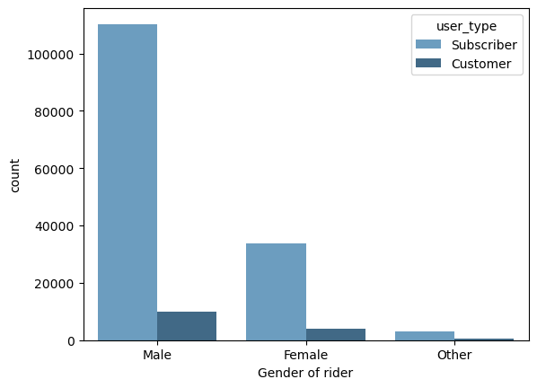

```python
# Barplot of Gender and user type
sb.countplot(data = fordgobike_clean, x = 'member_gender', hue = 'user_type', palette = 'Blues_d', order = gender_order)
plt.xlabel('Gender of rider');
```

There were more subcribers than customers across the gender

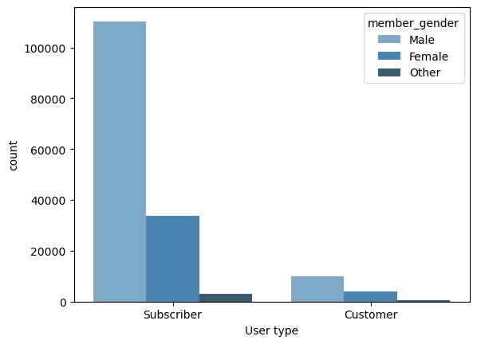

```python
# Barplot of gender and user type
sb.countplot(data = fordgobike_clean, hue = 'member_gender', x = 'user_type', palette = 'Blues_d')
plt.xlabel('User type');
```

There were more males riders than female and other gender across all user type

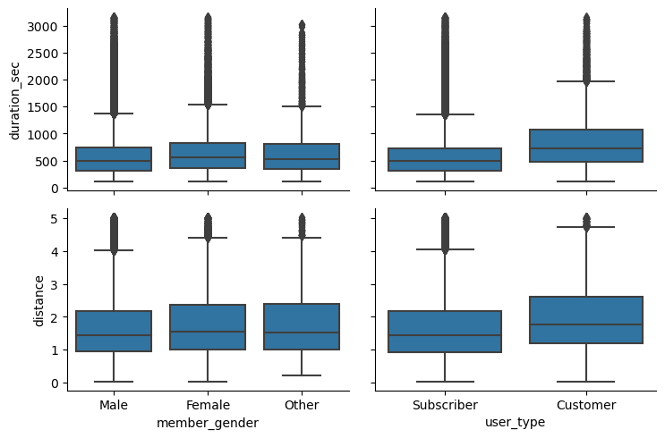

```python
# Create boxplot of numerical variables against categorical variaibles
def boxgrid(x, y, **kwargs):
    """ This helps in Creating box plots with seaborn's PairGrid as quickly as possible.
        the function should be passed as an Argument into Seaborn.PairGrid.map

        Args:
             x: x
             y: y
        kwargs: This take any keyword parameters that is acceptable by seaborn.boxplot
    """
    sb.boxplot(x, y, color = default_color)

plt.figure(figsize = [11.69, 8.27])
g = sb.PairGrid(data = fordgobike_clean, y_vars = ['duration_sec', 'distance'], x_vars = ['member_gender', 'user_type'],
                aspect = 1.5)
g.map(boxgrid);
```

```python
g
```

The median duration of ride were higher among the female riders and the customers while the average distance covered was about the same for the female and other gender with the male covering the least distance and the customers tends to cover more distance

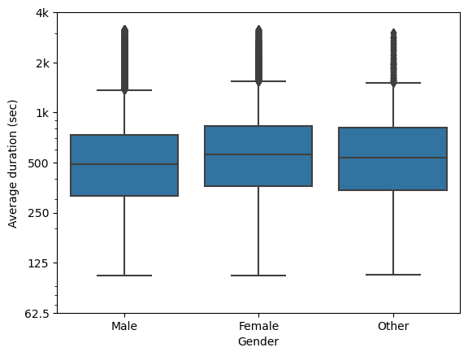

```python
# Boxplot of duration and gender
sb.boxplot(data = fordgobike_clean, x = 'member_gender', y = 'duration_sec', color = default_color)
plt.yscale('log')
plt.yticks([62.5, 125, 250, 500, 1000, 2000, 4000], [62.5, 125, 250, 500, '1k', '2k', '4k'])
plt.ylabel('Average duration (sec)')
plt.xlabel('Gender');
```

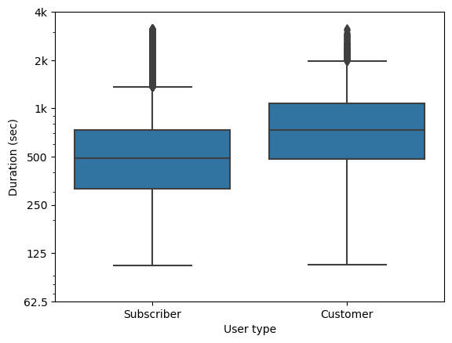

```python
# Boxplot of duration and user type
sb.boxplot(data = fordgobike_clean, x = 'user_type', y = 'duration_sec', color = default_color)
plt.yscale('log')
plt.yticks([62.5, 125, 250, 500, 1000, 2000, 4000], [62.5, 125, 250, 500, '1k', '2k', '4k'])
plt.ylabel('Duration (sec)')
plt.xlabel('User type');
```

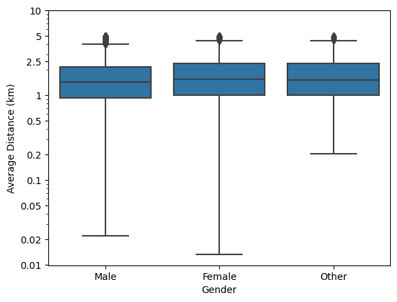

```python
# Boxplot of distance and gender
sb.boxplot(data = fordgobike_clean, x = 'member_gender', y = 'distance', color = default_color)
plt.yscale('log')
plt.yticks([0.01, 0.02, 0.05, 0.1, 0.2, 0.5, 1, 2.5, 5, 10], [0.01, 0.02, 0.05, 0.1, 0.2, 0.5, 1, 2.5, 5, 10])
plt.ylabel('Average Distance (km)')
plt.xlabel('Gender');
```

### Did you observe any interesting relationships between the other features (not the main feature(s) of interest)?

> Other gender and female gender tends to cover more average distance compared to the males which may have resulted to the males gender having the least average duration. Also, subscriber are more common among the genders.

## Multivariate Exploration

> Create plots of three or more variables to investigate your data even further. Make sure that your investigations are justified, and follow from your work in the previous sections.

#### Lets assess the relationship between duration and distance based on gender

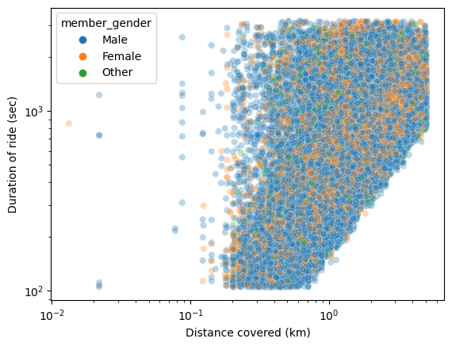

```python
# Scatter plot of duration and distance based on gender
sb.scatterplot(data = fordgobike_clean, x = 'distance', y = 'duration_sec', alpha = 0.3, hue = 'member_gender')
plt.yscale('log')
plt.xscale('log')
plt.xlabel('Distance covered (km)')
plt.ylabel('Duration of ride (sec)');
```

The scatter plot above shows a positive correlation between duration of ride and distance covered across all gender

#### Lets assess the relationship between duration and distance based on gender and user type

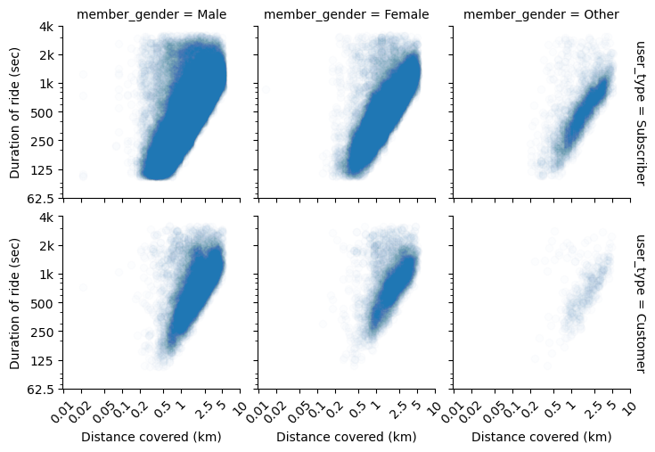

```python
# facet grid Scatter plot of duration and distance based on gender and user type
g = sb.FacetGrid(data = fordgobike_clean, col = 'member_gender', row = 'user_type', height = 2.5,
                margin_titles = True)
g.map(plt.scatter, 'distance', 'duration_sec', alpha = 0.01)
g.set_axis_labels( 'Distance covered (km)' , 'Duration of ride (sec)' )

plt.yscale('log')
plt.xscale('log')
g.set(yticks = [62.5, 125, 250, 500, 1000, 2000, 4000] , yticklabels = [62.5, 125, 250, 500, '1k', '2k', '4k'])
g.set(xticks = [0.01, 0.02, 0.05, 0.1, 0.2, 0.5, 1, 2.5, 5, 10] , xticklabels = [0.01, 0.02, 0.05, 0.1, 0.2, 0.5, 1, 2.5, 5, 10])
g.set_xticklabels(rotation=45);
```

The scatter plot above shows a positive correlation between duration of ride and distance covered across all gender and user type while also confirming that majority of the riders represented in the dataset were males and subscribers

#### Lets assess the relationship between duration and age based on gender and user type

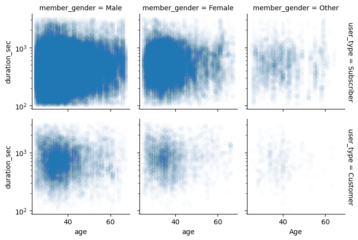

```python
# facet grid Scatter plot of duration and age based on gender and user type
g = sb.FacetGrid(data = fordgobike_clean, col = 'member_gender', row = 'user_type', height = 2.5,
                margin_titles = True)
g.map(plt.scatter, 'age', 'duration_sec', alpha = 0.01)

plt.yscale('log')
plt.xlabel('Age')
plt.ylabel('Duration of ride (sec)');
```

No significant relationship between duration and age of rider were observed across the gender and user type

#### Lets assess the relationship between distance and age based on gender and user type

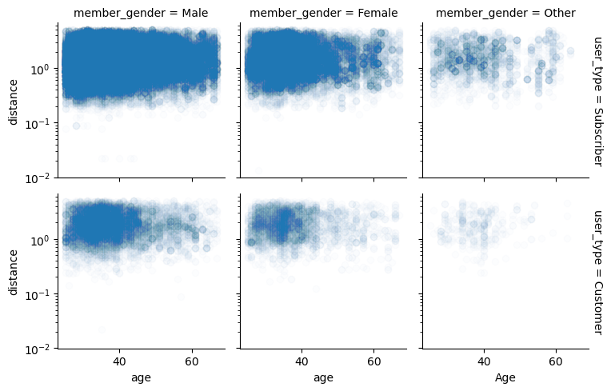

```python
# facet grid Scatter plot of distance and age based on gender and user type
g = sb.FacetGrid(data = fordgobike_clean, col = 'member_gender', row = 'user_type', height = 2.5,
                margin_titles = True)
g.map(plt.scatter, 'age', 'distance', alpha = 0.01)

plt.yscale('log')
plt.xlabel('Age')
plt.ylabel('Duration of ride (sec)');
```

No significant relationship between distance convered and age of rider were observed across the gender and user type

#### Lets explore the average duration of ride based on gender and user type

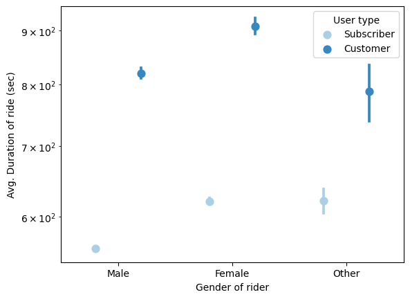

```python
# Point plot of duration against gender based on user type
sb.pointplot(data = fordgobike_clean, x = 'member_gender', y = 'duration_sec', hue = 'user_type',
           palette = 'Blues', linestyles = '', dodge = 0.4)
plt.yscale('log')
plt.xlabel('Gender of rider')
plt.ylabel('Avg. Duration of ride (sec)')
plt.legend(title = 'User type');
```

The average duration of ride based on gender and user type type shows that the Female gender and customers spend more time to completed rides

### Talk about some of the relationships you observed in this part of the investigation. Were there features that strengthened each other in terms of looking at your feature(s) of interest?

> There is a positive linear correlation between duration of ride in seconds and the distance covered across the different gender orientations and usertypes

### Were there any interesting or surprising interactions between features?

> one would expect that there should be some positive correlation between age of rider and the distance covered or duration but surprisingly there wasn't.

## Conclusions

> You can write a summary of the main findings and reflect on the steps taken during the data exploration.

Fordgobike data that includes information on individual bike rides were explored by first looking at the distribution of the main variable of interest which is the duration in seconds that it takes for riders to complete a ride and it showed a distribution with long tail which was subsequently transformed to log, each of the other variable of interests were also explored individually as well as collectively. The relationship between duration and other variables such as distance covered, gender, user type and age showed a positive correlation between duration and distance across the gender and user type even though the female gender had a higher median distance covered and consequently duration used while there were not significant correlations found between age and distance covered or duration

> At the end of your report, make sure that you export the notebook as an html file from the `File > Download as... > HTML or PDF` menu. Make sure you keep track of where the exported file goes, so you can put it in the same folder as this notebook for project submission. Also, make sure you remove all of the quote-formatted guide notes like this one before you finish your report!

```python
fordgobike_clean.to_csv('fordgobike_clean.csv', index=False)
```